# Take-Home Exercise 2

Take-Home Exercise 1 Take-2

Lee Xiao Qi https://example.com/norajones (School of Computing and Information Systems (SMU))https://example.com/spacelysprokets  
2022-05-01

# The Task

In this take-home exercise, we are required to:

1. select one of the [Take-home Exercise 1](https://isss608-ay2021-22april.netlify.app/th_ex/th_ex01) prepared by our classmate
2. critic the submission in terms of clarity and aesthetics, and
3. remake the original design by using the data visualisation principles and best practice we had learned in Lesson 1 and 2.

# The Classmate’s Take-Home Exercise 1

I have selected Che Xuan’s [submission](https://r4dsa4va.netlify.app/th_ex/th_ex1.html) for this exercise.

Following are the charts in the submission:

1. Bar Chart on household size and education level
2. Trellis Boxplot for joviality distribution of the participants across interest groups by kids
3. Raincoud Plots for joviality spread of the participants across the education levels
4. Ridge Plot for joviality spread of the participants across the interest groups
5. Composite Plot that patch s/n 1 to 4 into one canvas.

For simplicity, all codes from the original submission will not be showed in this webpage. You may refer to Che Xuan’s [webpage](https://r4dsa4va.netlify.app/th_ex/th_ex1.html) for more information.

# The Required Packages and Data

These packages **tidyverse** (including **dplyr**, **magrittr**, **ggplot2**, **patchwork**, **ggdist**, **tidyquant**), **ggrepel**,**ggdist**, **ggridges**, **patchwork**, **ggthemes** will be used for the purpose of this exercise.

The code chunk below is used to install and load the required packages onto RStudio. We will also import *Participants.csv* from the data folder into R by using `read_csv()` and save it as an tibble data frame called *demographic_data*.

```r
packages = c('tidyverse','ggrepel','ggdist', 'ggridges', 'patchwork', 'ggthemes')

for(p in packages){
  if(!require(p, character.only =T)){
    install.packages(p)
    }
  library(p, character.only =T)
}
```

```r
demographic_data <- read_csv("data/Participants.csv")
```

```r
#check the data
library(dplyr)
demographic_data %>%
  glimpse()
```

```
Rows: 1,011
Columns: 7
$ participantId  <dbl> 0, 1, 2, 3, 4, 5, 6, 7, 8, 9, 10, 11, 12, 13,~
$ householdSize  <dbl> 3, 3, 3, 3, 3, 3, 3, 3, 3, 3, 3, 3, 3, 3, 3, ~
$ haveKids       <lgl> TRUE, TRUE, TRUE, TRUE, TRUE, TRUE, TRUE, TRU~
$ age            <dbl> 36, 25, 35, 21, 43, 32, 26, 27, 20, 35, 48, 2~
$ educationLevel <chr> "HighSchoolOrCollege", "HighSchoolOrCollege",~
$ interestGroup  <chr> "H", "B", "A", "I", "H", "D", "I", "A", "G", ~
$ joviality      <dbl> 0.001626703, 0.328086500, 0.393469590, 0.1380~
```

# The Data Wrangling

In my own submission for **Take-Home Exercise 1**, I have provided a brief description and conducted a series of data exploration and wrangling on the dataset. You may wish to visit this [page](https://tiffanylxq.netlify.app/takehomeex/th_ex1) for more information.

For the purpose of this exercise, I will retain the author’s approach and will only make changes to his/her charts from a data visualisation point of view.

First, we start by renaming the columns and values of in *demographic_data* file using the function [`rename()`](https://dplyr.tidyverse.org/reference/rename.html), and [`sub()`](https://www.datasciencemadesimple.com/sub-gsub-function-in-r/) for a better format and ease of reading.

```r
# rename columns
demographic_data <- demographic_data %>%
  rename('Participant_ID' = 'participantId',
         'Household_Size' = 'householdSize',
         'Have_Kids' = 'haveKids',
         'Age' = 'age',
         'Education_Level' = 'educationLevel',
         'Interest_Group' = 'interestGroup',
         'Joviality' = 'joviality')

#rename row values
demographic_data$Education_Level <- sub('HighSchoolOrCollege',
                                    'High School or College',
                                    demographic_data$Education_Level)

demographic_data$Have_Kids <- sub('TRUE',
                                    'Yes',
                                    demographic_data$Have_Kids)

demographic_data$Have_Kids <- sub('FALSE',
                                    'No',
                                    demographic_data$Have_Kids)
```

# The Makeover

Next, we look at each chart one by one.

### 1) Bar Chart on Household Size & Education level

**Clarity**:

(+) It is helpful to include a plot title and rename the y and x-axis label for better understanding of the charts. The appended statistics also helps users to see the difference in size among the household sizes.

(-) However, given that there are only 3 household sizes (1,2,3), there may not be a need to rearrange the bar in descending order. In this case. retaining the x-axis order may allow user to interpret quickly and intuitively what are the most and least common household size among the participants. A summary on the chart findings could also be helpful for the user.

**Aesthetics**:

(+) Setting y-axis limit is helpful to see clearly the data label.

(-) Orientation of the y-axis label could be changed for ease of reading.

**Changes**:

Other than addressing the (-) above, we also:

1. uses the `theme()` function to lighten the background to enhance the dark grey bar charts, centralise the plot title and increase its font size
2. uses the *axis* argument to change the y-axis label orientation, panel color, axis color
3. the renamed data value of the educational level will serve to improve the readability of the x-axis
4. included an annotation on the our observations
5. customise the figure size to make it bigger

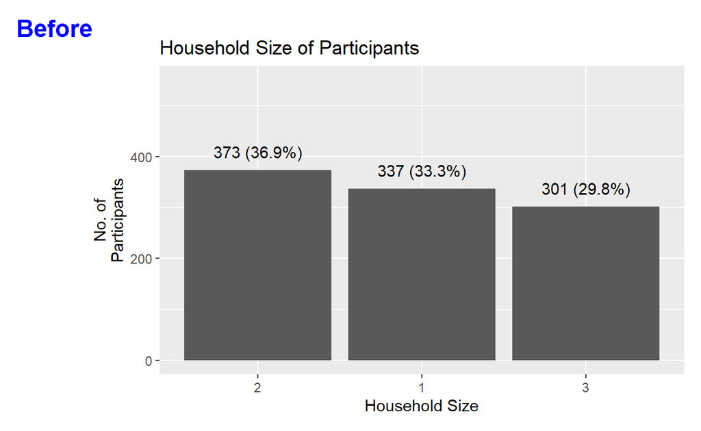

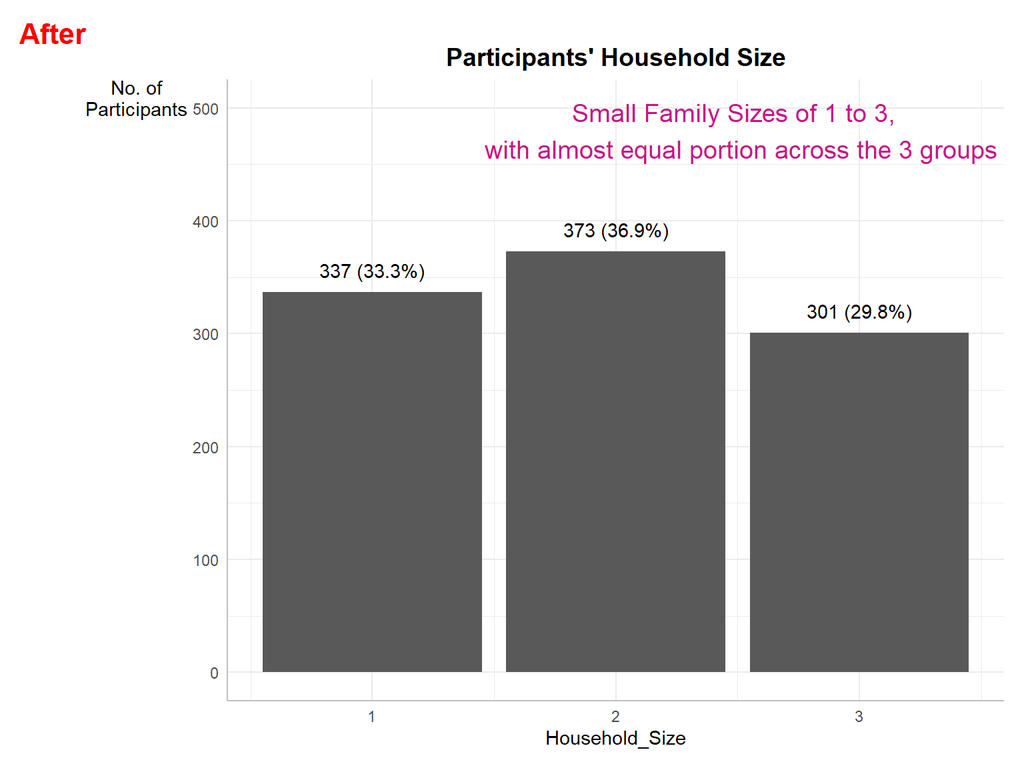

```r
p1b <- ggplot(data = demographic_data,
       aes(x=Household_Size)) +
  geom_bar() +
  ylim(0,500) +
  geom_text(stat="count",
      aes(label=paste0(..count.., " (",
      round(..count../sum(..count..)*100,
            1), "%)")),
      vjust=-1) +
  ylab("No. of\nParticipants") +
  ggtitle("Participants' Household Size")+
  theme_minimal()+
  theme(plot.title = element_text(size=14, face="bold",hjust = 0.5),
          plot.subtitle = element_text(hjust = 0.5))+
  theme(axis.title.y= element_text(angle=0), axis.ticks.x= element_blank(),
        panel.background= element_blank(), axis.line= element_line(color= 'grey'))+
  annotate("text",
           x = 2.5,
           y = 480,
           label = "Small Family Sizes of 1 to 3, \n with almost equal portion across the 3 groups",size=5,color='mediumvioletred')
```

**The same observations are made for the bar chart on education level and hence similar changes are applied.**

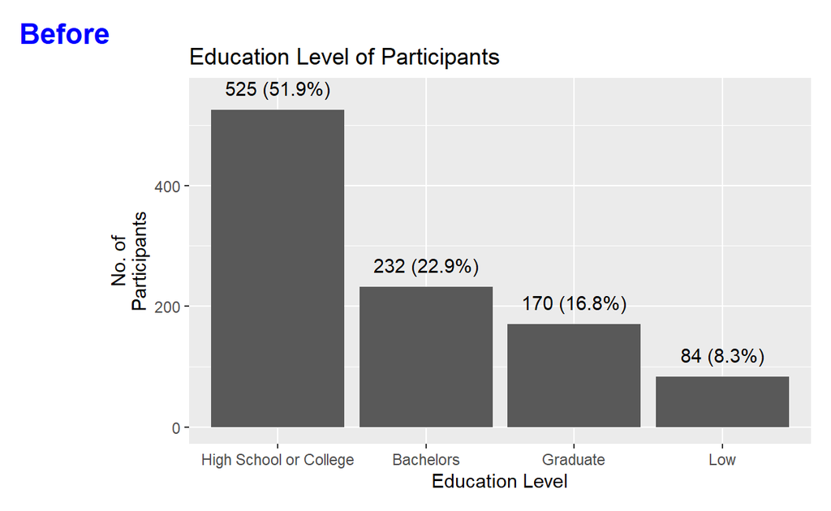

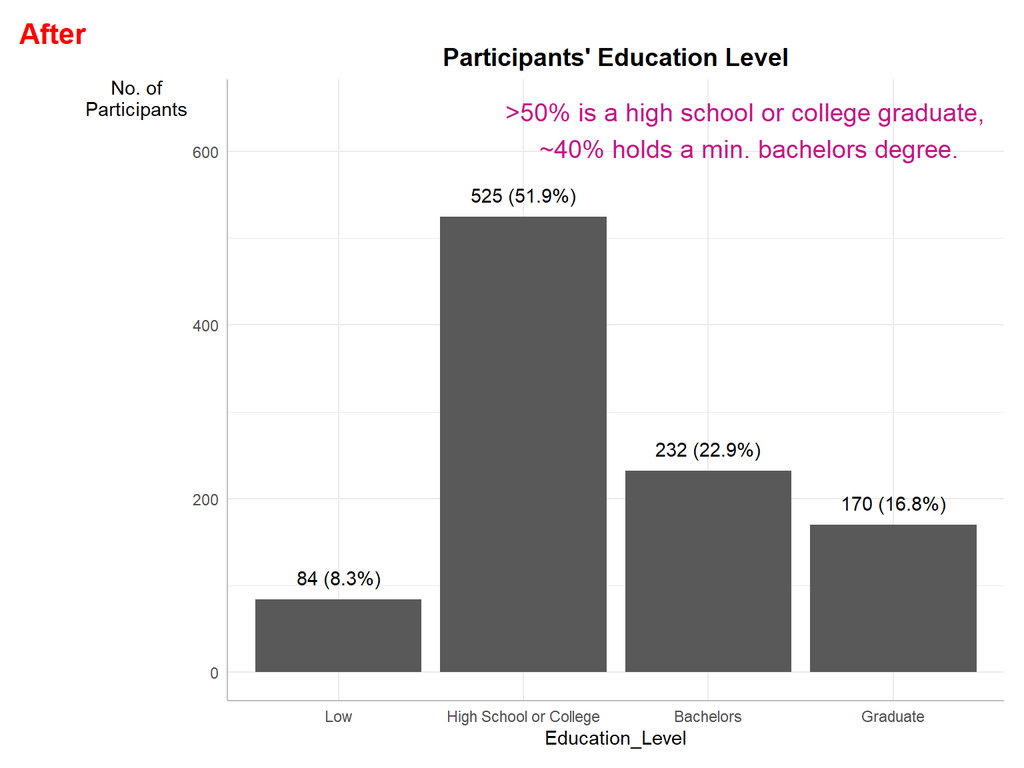

```r
demographic_data$Education_Level = factor(demographic_data$Education_Level, levels = c('Low', 'High School or College', 'Bachelors','Graduate'))

p2b <- ggplot(data = demographic_data,
       aes(x=Education_Level)) +
  geom_bar() +
  ylim(0,650) +
  geom_text(stat="count",
      aes(label=paste0(..count.., " (",
      round(..count../sum(..count..)*100,
            1), "%)")),
      vjust=-1) +
  ylab("No. of\nParticipants") +
  ggtitle("Participants' Education Level")+
  theme_minimal()+
  theme(plot.title = element_text(size=14, face="bold",hjust = 0.5),
          plot.subtitle = element_text(hjust = 0.5))+
  theme(axis.title.y= element_text(angle=0), axis.ticks.x= element_blank(),
        panel.background= element_blank(), axis.line= element_line(color= 'grey'))+
  annotate("text",
           x = 3.2,
           y = 625,
           label = ">50% is a high school or college graduate,\n ~40% holds a min. bachelors degree.",size=5,color='mediumvioletred')
```